# Prediction assigment

Pierrot Pascal

15 mars 2016

# Introduction

Using devices such as Jawbone Up, Nike FuelBand, and Fitbit it is now possible to collect a large amount of data about personal activity relatively inexpensively. These type of devices are part of the quantified self movement - a group of enthusiasts who take measurements about themselves regularly to improve their health, to find patterns in their behavior, or because they are tech geeks. One thing that people regularly do is quantify how much of a particular activity they do, but they rarely quantify how well they do it. In this project, the goal will be to use data from accelerometers on the belt, forearm, arm, and dumbell of 6 participants. In this project, we will want to predict the manner in which they did the exercise. This is the “classe” variable in the training set.

Data sets which will be used are taken from this url :

https://d396qusza40orc.cloudfront.net/predmachlearn/pml-training.csv

https://d396qusza40orc.cloudfront.net/predmachlearn/pml-testing.csv

# Data exploratory analysis and cleaning

In order to clean the data set , we first have a quick look to the training data

```r
dat= as.data.frame(read.csv("training.csv"))
head(dat, n=1)
```

```
##   X user_name raw_timestamp_part_1 raw_timestamp_part_2   cvtd_timestamp
## 1 1  carlitos           1323084231               788290 05/12/2011 11:23
##   new_window num_window roll_belt pitch_belt yaw_belt total_accel_belt
## 1         no         11      1.41       8.07    -94.4                3
##   kurtosis_roll_belt kurtosis_picth_belt kurtosis_yaw_belt
## 1
##   skewness_roll_belt skewness_roll_belt.1 skewness_yaw_belt max_roll_belt
## 1                                                                      NA
##   max_picth_belt max_yaw_belt min_roll_belt min_pitch_belt min_yaw_belt
## 1             NA                         NA             NA
##   amplitude_roll_belt amplitude_pitch_belt amplitude_yaw_belt
## 1                  NA                   NA
##   var_total_accel_belt avg_roll_belt stddev_roll_belt var_roll_belt
## 1                   NA            NA               NA            NA
##   avg_pitch_belt stddev_pitch_belt var_pitch_belt avg_yaw_belt
## 1             NA                NA             NA           NA
##   stddev_yaw_belt var_yaw_belt gyros_belt_x gyros_belt_y gyros_belt_z
## 1              NA           NA            0            0        -0.02
##   accel_belt_x accel_belt_y accel_belt_z magnet_belt_x magnet_belt_y
## 1          -21            4           22            -3           599
##   magnet_belt_z roll_arm pitch_arm yaw_arm total_accel_arm var_accel_arm
## 1          -313     -128      22.5    -161              34            NA
##   avg_roll_arm stddev_roll_arm var_roll_arm avg_pitch_arm stddev_pitch_arm
## 1           NA              NA           NA            NA               NA
##   var_pitch_arm avg_yaw_arm stddev_yaw_arm var_yaw_arm gyros_arm_x
## 1            NA          NA             NA          NA           0
##   gyros_arm_y gyros_arm_z accel_arm_x accel_arm_y accel_arm_z magnet_arm_x
## 1           0       -0.02        -288         109        -123         -368
##   magnet_arm_y magnet_arm_z kurtosis_roll_arm kurtosis_picth_arm
## 1          337          516
##   kurtosis_yaw_arm skewness_roll_arm skewness_pitch_arm skewness_yaw_arm
## 1
##   max_roll_arm max_picth_arm max_yaw_arm min_roll_arm min_pitch_arm
## 1           NA            NA          NA           NA            NA
##   min_yaw_arm amplitude_roll_arm amplitude_pitch_arm amplitude_yaw_arm
## 1          NA                 NA                  NA                NA
##   roll_dumbbell pitch_dumbbell yaw_dumbbell kurtosis_roll_dumbbell
## 1      13.05217        -70.494    -84.87394
##   kurtosis_picth_dumbbell kurtosis_yaw_dumbbell skewness_roll_dumbbell
## 1
```

[output cut: 25 more lines]

```
## 1                NA                               NA                NA
##   min_yaw_forearm amplitude_roll_forearm amplitude_pitch_forearm
## 1                                     NA                      NA
##   amplitude_yaw_forearm total_accel_forearm var_accel_forearm
## 1                                        36                NA
##   avg_roll_forearm stddev_roll_forearm var_roll_forearm avg_pitch_forearm
## 1               NA                  NA               NA                NA
##   stddev_pitch_forearm var_pitch_forearm avg_yaw_forearm
## 1                   NA                NA              NA
##   stddev_yaw_forearm var_yaw_forearm gyros_forearm_x gyros_forearm_y
## 1                 NA              NA            0.03               0
##   gyros_forearm_z accel_forearm_x accel_forearm_y accel_forearm_z
## 1           -0.02             192             203            -215
##   magnet_forearm_x magnet_forearm_y magnet_forearm_z classe
## 1              -17              654              476      A
```

We can see that there are NA values and empty spaces. Thus, we omit these values. Beside, many non-numeric variables such as user names or timestamp are not workable for our model, so we decide to remove them from the dataset. We remove also columns in which there are NA values.

```r
data1 = read.csv("training.csv", na.strings=c("NA",""), strip.white=TRUE)
data2 = as.data.frame(data1)
data3 = subset(data2, select = -c(X, user_name, raw_timestamp_part_1,
raw_timestamp_part_2, cvtd_timestamp, new_window, num_window))
haveNA = apply(data3,2,  function(x) {sum(is.na(x))})
data4 = data3[,which(haveNA==0)]
```

# Creating data partitions

In order to use cross validation for our model, the training data set is splitd into one training (3/4 of data) set and one cross-validation set (1/4 of data). The cross-validation set will help us to see how the model performs on a new dataset and prevent overfitting.

```r
library(caret)
inTrain = createDataPartition(data4$classe, p = 0.75, list = FALSE)
training = data4[inTrain,]
testing = data4[-inTrain,]
```

# Dimension reduction using PCA

In this section, we will preprocess data by using PCA in order to simplify the analysis and interpretation. First, we check the existence of possible correlations between variables by computing the correlation matrix.

```r
##seeking strong correlation between variables
M = abs(cor(training[,-53]))
diag(M) = 0
head(which(M>0.9, arr.ind = T), n=7)
```

```
##                  row col
## total_accel_belt   4   1
## accel_belt_y       9   1
## accel_belt_z      10   1
## accel_belt_x       8   2
## roll_belt          1   4
## accel_belt_y       9   4
## accel_belt_z      10   4
```

We can see that there are many correlations between some variables. Thus, it is relevant to perform a PCA with the preprocessing command.

```r
preProc = preProcess(training[,-53], method = "pca", thresh = 0.9)
train = predict(preProc, training[,-53])
test = predict(preProc, testing[,-53])
dim(train)
```

```
## [1] 14718    18
```

The PCA method has kept 18 variables from the data set. Once we have our training set “train” and cross-validation set “test” we can begin our model selection

# First model with decision trees

```r
library(rpart)
library(rpart.plot)
treeModel = rpart(training$classe~., data = train, method = "class")
predTest = predict(treeModel, test, type = "class")
predTrain = predict(treeModel, train, type = "class")
confusionMatrix(testing$classe, predTest)
```

```
## Confusion Matrix and Statistics
##
##           Reference
## Prediction    A    B    C    D    E
##          A 1192   25   66   85   27
##          B  385  246   71   92  155
##          C  567   34  135   40   79
##          D  251   60  108  258  127
##          E  273  110   34   68  416
##
## Overall Statistics
##
##                Accuracy : 0.4582
##                  95% CI : (0.4442, 0.4723)
##     No Information Rate : 0.544
##     P-Value [Acc > NIR] : 1
##
##                   Kappa : 0.2904
##  Mcnemar's Test P-Value : <2e-16
##
## Statistics by Class:
##
##                      Class: A Class: B Class: C Class: D Class: E
## Sensitivity            0.4468  0.51789  0.32609  0.47514  0.51741
## Specificity            0.9092  0.84127  0.83964  0.87480  0.88171
## Pos Pred Value         0.8545  0.25922  0.15789  0.32090  0.46171
## Neg Pred Value         0.5794  0.94210  0.93109  0.93049  0.90307
## Prevalence             0.5440  0.09686  0.08442  0.11073  0.16395
## Detection Rate         0.2431  0.05016  0.02753  0.05261  0.08483
## Detection Prevalence   0.2845  0.19352  0.17435  0.16395  0.18373
## Balanced Accuracy      0.6780  0.67958  0.58287  0.67497  0.69956
```

```r
confusionMatrix(training$classe, predTrain)
```

```
## Confusion Matrix and Statistics
##
##           Reference
## Prediction    A    B    C    D    E
##          A 3548   79  203  282   73
##          B 1314  613  233  271  417
##          C 1642  103  450   93  279
##          D  745  136  264  839  428
##          E  833  337   80  217 1239
##
## Overall Statistics
##
##                Accuracy : 0.4545
##                  95% CI : (0.4464, 0.4626)
##     No Information Rate : 0.5491
##     P-Value [Acc > NIR] : 1
##
##                   Kappa : 0.2852
##  Mcnemar's Test P-Value : <2e-16
##
## Statistics by Class:
##
##                      Class: A Class: B Class: C Class: D Class: E
## Sensitivity            0.4390  0.48344  0.36585  0.49295  0.50862
## Specificity            0.9040  0.83383  0.84305  0.87915  0.88056
## Pos Pred Value         0.8478  0.21524  0.17530  0.34784  0.45787
## Neg Pred Value         0.5695  0.94482  0.93581  0.92987  0.90035
## Prevalence             0.5491  0.08615  0.08357  0.11564  0.16551
## Detection Rate         0.2411  0.04165  0.03057  0.05701  0.08418
## Detection Prevalence   0.2843  0.19350  0.17441  0.16388  0.18386
## Balanced Accuracy      0.6715  0.65863  0.60445  0.68605  0.69459
```

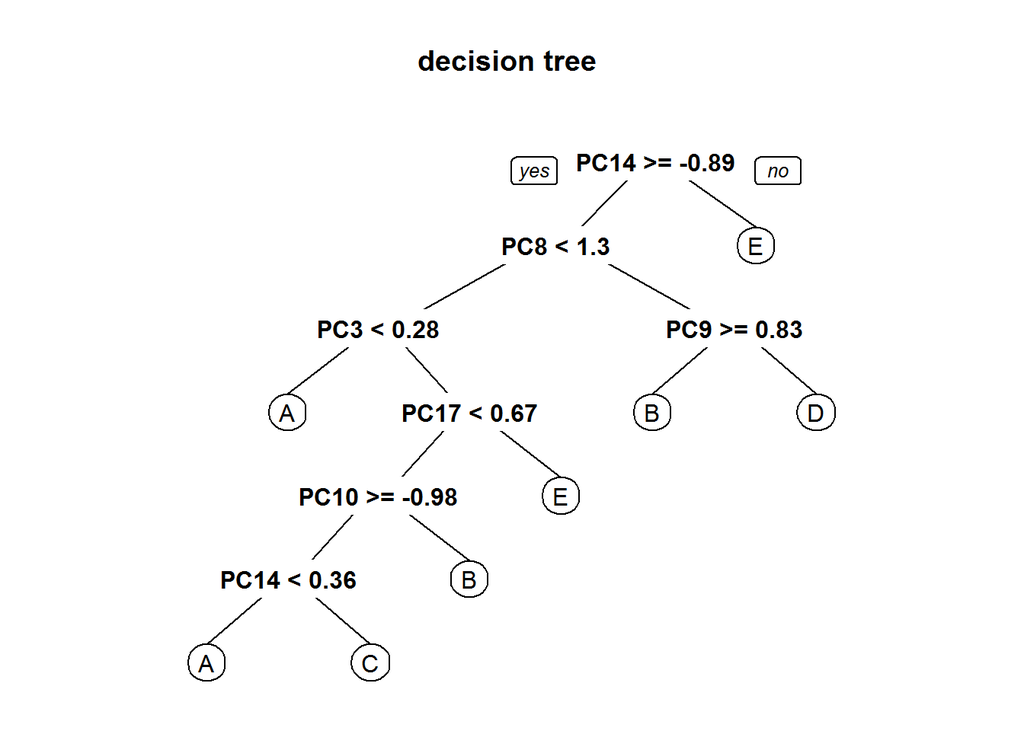

```r
rpart.plot(treeModel, main ="decision tree ")
```

# A second approach using random forest

In order to improve the accuracy result, a random forest method will be fitted. The asset of such a method is that it will use several trees on differents sample of the training set and will proceed to a majority vote. Thus, we expected to have a better accuracy with this method.

```r
library(randomForest)
ctrl <- trainControl(allowParallel=T, method="cv", number=4)
rfmodel = train(training$classe~., data = train, method = "rf", trControl=ctrl)
rfpredTest = predict(rfmodel, newdata = test)
confusionMatrix(rfpredTest, testing$classe)
```

```
## Confusion Matrix and Statistics
##
##           Reference
## Prediction    A    B    C    D    E
##          A 1389   19    5    0    0
##          B    1  919   12    0    1
##          C    4   11  827   44    5
##          D    0    0   10  758    6
##          E    1    0    1    2  889
##
## Overall Statistics
##
##                Accuracy : 0.9751
##                  95% CI : (0.9704, 0.9793)
##     No Information Rate : 0.2845
##     P-Value [Acc > NIR] : < 2.2e-16
##
##                   Kappa : 0.9685
##  Mcnemar's Test P-Value : NA
##
## Statistics by Class:
##
##                      Class: A Class: B Class: C Class: D Class: E
## Sensitivity            0.9957   0.9684   0.9673   0.9428   0.9867
## Specificity            0.9932   0.9965   0.9842   0.9961   0.9990
## Pos Pred Value         0.9830   0.9850   0.9282   0.9793   0.9955
## Neg Pred Value         0.9983   0.9924   0.9930   0.9889   0.9970
## Prevalence             0.2845   0.1935   0.1743   0.1639   0.1837
## Detection Rate         0.2832   0.1874   0.1686   0.1546   0.1813
## Detection Prevalence   0.2881   0.1903   0.1817   0.1578   0.1821
## Balanced Accuracy      0.9944   0.9824   0.9757   0.9694   0.9928
```

# Cases prediction

## Using decision trees

```r
testdata = read.csv("testing.csv", na.strings=c("NA",""), strip.white=T)
usernames = testdata$user_name ##will be usefull for the continuation
ntestdata = subset(testdata, select = -c(X, user_name, raw_timestamp_part_1,
                                raw_timestamp_part_2, cvtd_timestamp, new_window, num_window))
predtestn = predict(preProc, ntestdata) ##pre-process
p=predict(treeModel, predtestn)
data.frame(usernames, p)
```

```
##    usernames          A         B          C          D          E
## 1      pedro 0.45517444 0.1430885 0.22788164 0.08552922 0.08832622
## 2     jeremy 0.45517444 0.1430885 0.22788164 0.08552922 0.08832622
## 3     jeremy 0.45517444 0.1430885 0.22788164 0.08552922 0.08832622
## 4     adelmo 0.45517444 0.1430885 0.22788164 0.08552922 0.08832622
## 5     eurico 0.35376261 0.2653220 0.07292475 0.12723041 0.18076028
## 6     jeremy 0.45517444 0.1430885 0.22788164 0.08552922 0.08832622
## 7     jeremy 0.16568743 0.1592244 0.05464160 0.49294947 0.12749706
## 8     jeremy 0.45517444 0.1430885 0.22788164 0.08552922 0.08832622
## 9   carlitos 0.45517444 0.1430885 0.22788164 0.08552922 0.08832622
## 10   charles 0.45517444 0.1430885 0.22788164 0.08552922 0.08832622
## 11  carlitos 0.45517444 0.1430885 0.22788164 0.08552922 0.08832622
## 12    jeremy 0.45517444 0.1430885 0.22788164 0.08552922 0.08832622
## 13    eurico 0.35376261 0.2653220 0.07292475 0.12723041 0.18076028
## 14    jeremy 0.45517444 0.1430885 0.22788164 0.08552922 0.08832622
## 15    jeremy 0.35376261 0.2653220 0.07292475 0.12723041 0.18076028
## 16    eurico 0.35376261 0.2653220 0.07292475 0.12723041 0.18076028
## 17     pedro 0.45517444 0.1430885 0.22788164 0.08552922 0.08832622
## 18  carlitos 0.16504065 0.1894309 0.36585366 0.21463415 0.06504065
## 19     pedro 0.45517444 0.1430885 0.22788164 0.08552922 0.08832622
## 20    eurico 0.03087248 0.2234899 0.03691275 0.13825503 0.57046980
```

## Using random forest

```r
predCase = predict(rfmodel, predtestn)
result = data.frame(usernames, predCase)
result
```

```
##    usernames predCase
## 1      pedro        B
## 2     jeremy        A
## 3     jeremy        A
## 4     adelmo        A
## 5     eurico        A
## 6     jeremy        E
## 7     jeremy        D
## 8     jeremy        B
## 9   carlitos        A
## 10   charles        A
## 11  carlitos        B
## 12    jeremy        C
## 13    eurico        B
## 14    jeremy        A
## 15    jeremy        E
## 16    eurico        E
## 17     pedro        A
## 18  carlitos        B
## 19     pedro        B
## 20    eurico        B
```

# Conclusion

Using a random forest was far more interesting in our case because it provides a better accuracy. Owing to the high number of variables and the presence of possible correlations, I decided to perform a dimension reduction first. The asset of this step is that it makes the interpretation and the analysis of the output decision tree easier. Nevertheless, dimension reduction like PCA remove information and this might have led to worse results with decision tree methods.